# Reproducible Research: Peer Assessment 1

```r
## prevent markdown from showing scientific notation for small numbers
options(scipen = 999, digits = 2)
```

## Loading and preprocessing the data

The following code will load and process the data:

```r
## check if file exists and extract zip if necessary
if(!file.exists("data/activity.csv")) {
    unzip("activity.zip", exdir = "data")
}

## read data and convert date column to date format
data <- read.csv("./data/activity.csv", stringsAsFactors = FALSE)
data$date <- as.Date(data$date)
```

## What is mean total number of steps taken per day?

The *dplyr* library will be used to aggregate daily totals. The histogram is plotted with the base plotting package:

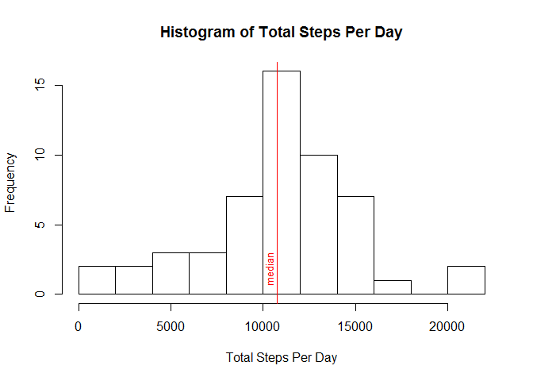

```r
## use dplyr library to calculate total steps per day
library(dplyr)

stepsPerDay <- data %>%
    group_by(date) %>%
    summarize(totalSteps = sum(steps))

## calculate mean and median values
meanSteps <- mean(stepsPerDay$totalSteps, na.rm=TRUE)
medianSteps <- median(stepsPerDay$totalSteps, na.rm=TRUE)

## plot histogram of total steps per day
hist(stepsPerDay$totalSteps,
     xlab = "Total Steps Per Day",
     main = "Histogram of Total Steps Per Day",
     breaks = 12)
abline(v = medianSteps, col = "red")            ## show median with red line
text(medianSteps, 3, "median",                  ## label median line
     pos = 2,
     offset = 0.5,
     srt = 90,
     col = "red",
     cex = 0.8)
```

### Results

Ignoring missing values, the mean steps per day is **10766.19** and the median steps per day is **10765**.

## What is the average daily activity pattern?

The *dplyr* library is used again to aggregate by 5-minute interval and the interval with the most average steps is found by sorting the data frame in decreasing order and taking the value from the first row value:

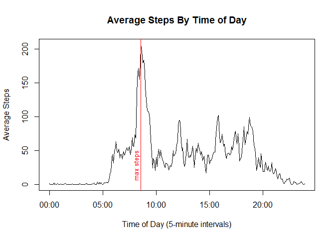

```r
## calculate mean steps per 5-minute interval
stepsPerInterval <- data %>%
    group_by(interval) %>%
    summarize(intervalSteps = mean(steps, na.rm = TRUE))


## convert interval to time format
stepsPerInterval$hour <- with(stepsPerInterval, substr(interval, nchar(interval)-3, nchar(interval)-2))

stepsPerInterval$hour[stepsPerInterval$hour==""] <- 0

stepsPerInterval$min <- stepsPerInterval$interval - as.numeric(stepsPerInterval$hour)*100

stepsPerInterval$time <- as.POSIXct(strptime(paste(stepsPerInterval$hour, stepsPerInterval$min, sep=":"), "%H:%M"))

## sort by decreasing average steps per interval and take first row
maxStepsInterval <- stepsPerInterval[order(stepsPerInterval$intervalSteps, decreasing = TRUE), ][1, ]$time

## plot average steps by time of day
with(stepsPerInterval,
    plot(time, intervalSteps,
                            type="l",
                            main = "Average Steps By Time of Day",
                            xlab = "Time of Day (5-minute intervals)",
                            ylab = "Average Steps"))
abline(v = as.numeric(maxStepsInterval), col = "red")     ## show interval with the max steps
text(maxStepsInterval, 50, "max steps",       ## label max steps line
     pos = 2,
     offset = 0.5,
     srt = 90,
     col = "red",
     cex = 0.8
)
```

### Results:

On average, the maximum number of steps occurs at **08:35**.

## Imputing missing values

Missing values will be imputed using the average steps for each interval.

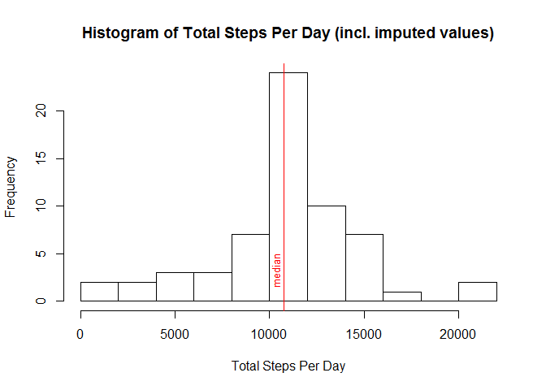

```r
## find number of NAs
missing <- sum(is.na(data$steps))

## use mean for 5-minute interval to impute missing values
dataImp <- merge(data, stepsPerInterval[,1:2], by = "interval")
dataImp$steps[is.na(dataImp$steps)] <- dataImp$intervalSteps[is.na(dataImp$steps)]

## recalculate total steps per day using imputed values
stepsPerDayImp <- dataImp %>%
    group_by(date) %>%
    summarize(totalSteps = sum(steps))

## calculate mean and median values
meanStepsImp <- mean(stepsPerDayImp$totalSteps)
medianStepsImp <- median(stepsPerDayImp$totalSteps)

## plot histogram of total steps per day
hist(stepsPerDayImp$totalSteps,
     xlab = "Total Steps Per Day",
     main = "Histogram of Total Steps Per Day (incl. imputed values)",
     breaks = 12)
abline(v = medianStepsImp, col = "red")            ## show median with red line
text(medianSteps, 5, "median",                     ## label median line
     pos = 2,
     offset = 0.5,
     srt = 90,
     col = "red",
     cex = 0.8)
```

### Results:

There are **2304** missing values in the original dataset. Including imputed values, the mean steps per day is **10766.19** and the median steps per day is **10766.19**.

Using the average steps per interval to impute values has the effect of keeping the mean stable. However, because there were a number of full days that were missing all values, these days all have identical, imputed values. This has biased the centre of the distribution, producing a median that is identical to the mean. While this is only a slight difference from the median that was calculated without missing values, the influence on the variance is larger.

## Are there differences in activity patterns between weekdays and weekends?

The *weekdays* function and the *lattice* package will be used to answer this question:

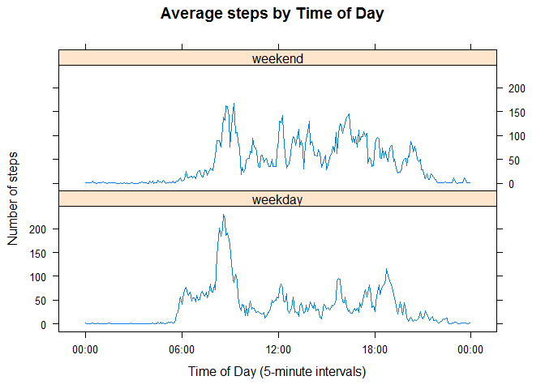

```r
library(lattice)

## identify weekdays and convert to factor variable
dataImp$weekday <- ifelse(weekdays(dataImp$date) == "Saturday" | weekdays(dataImp$date) == "Sunday", "weekend", "weekday")
dataImp$weekday <- as.factor(dataImp$weekday)

## use dplyr to take the interval mean by weekday/weekend
stepsByWeekday <- dataImp %>%
    group_by(weekday, interval) %>%
    summarize(mean = mean(steps))

## convert interval to time format
stepsByWeekday$hour <- with(stepsByWeekday, substr(interval, nchar(interval)-3, nchar(interval)-2))

stepsByWeekday$hour[stepsByWeekday$hour==""] <- 0

stepsByWeekday$min <- stepsByWeekday$interval - as.numeric(stepsByWeekday$hour)*100

stepsByWeekday$time <- as.POSIXct(strptime(paste(stepsByWeekday$hour, stepsByWeekday$min, sep=":"), "%H:%M"))

## plot in lattice
xyplot(mean ~ time | weekday,
       data = stepsByWeekday,
       type = "l",
       layout = c(1,2),
       main = "Average steps by Time of Day",
       xlab = "Time of Day (5-minute intervals)",
       ylab = "Number of steps",
      scales = list(
        x = list(
          format = "%H:%M"
        )
      )
)
```